[figure not shown]

© 2015-2018 Alexander C.S. Hendorf, [Königsweg GmbH](http://koenigsweg.com), Mannheim

```python
# set custom style, ignore this part
from IPython.display import HTML
style = "<style>.rendered_html tr,.rendered_html td {font-size: 12pt !important;}</style>"
HTML(style)
```

# Data Wrangling and Visualisation with Juypter and Pandas

# Jupyter Notebooks Intro

### Dashboard

- Access to your local filesystem (*root* = where you strarted Jupyter from)
- Notebook running (*running*)
- Create new notebooks, files and directories

[figure not shown]

### Navigation

- File
- Edit
- Insert
- Cell
- Kernel

### Areas & Cell Types

- Markdown cells
- Code cells
- Output area

**Markdown**

```python
print("Hello world!")
```

```
Hello world!
```

```python
a = "hello"
a
```

```
'hello'
```

The output of last line is sent to output by deafault no **`print()`** needed here.

```python
a = 12
b = 6
c = a / b
c
```

```
2.0
```

```python
a = 12
b = 6
a / b
```

```
2.0
```

Suppress output with a semicolon

```python
a = 12
b = 6
a / b;
```

### Extentions

Jupyter *may* be extended.  
Some extra installation is required:

```
conda install -c conda-forge jupyter_contrib_nbextensions
jupyter contrib nbextension install --user
```

After a restart of the notebook server extendtions can be switched on and off.

[figure not shown]

### Shortcuts

Shortcuts make you efficient and fast working with Jupyter. The most important ones.

Use

> ESC+m

to make a code cell a markdown cell. Use

> SHIFT+RETURN

to execute the cell, after the last cell a new cell is created by default.

| Mode | What | Shortcut |
| --- | --- | --- |
| Command (Press *Esc* to enter) | Run cell | Shift-Enter |
| Command | Add cell below | B |
| Command | Add cell above | A |
| Command | Delete a cell | d-d |
| Command | Go into edit mode | Enter |
| Edit (Press *Enter* to enable) | Run cell | Shift-Enter |
| Edit | Indent | Clrl-] |
| Edit | Unindent | Ctrl-[ |
| Edit | Comment section | Ctrl-/ |
| Edit | Function introspection | Shift-Tab |

See more shortcuts in the navigation menu.

## Getting inline help

Use a question mark to get help

```python
?
```

```
IPython -- An enhanced Interactive Python
=========================================

IPython offers a fully compatible replacement for the standard Python
interpreter, with convenient shell features, special commands, command
history mechanism and output results caching.

At your system command line, type 'ipython -h' to see the command line
options available. This document only describes interactive features.

GETTING HELP
------------

Within IPython you have various way to access help:

  ?         -> Introduction and overview of IPython's features (this screen).
  object?   -> Details about 'object'.
  object??  -> More detailed, verbose information about 'object'.
  %quickref -> Quick reference of all IPython specific syntax and magics.
  help      -> Access Python's own help system.

If you are in terminal IPython you can quit this screen by pressing `q`.


MAIN FEATURES
-------------

* Access to the standard Python help with object docstrings and the Python
  manuals. Simply type 'help' (no quotes) to invoke it.

* Magic commands: type %magic for information on the magic subsystem.

* System command aliases, via the %alias command or the configuration file(s).

* Dynamic object information:

  Typing ?word or word? prints detailed information about an object. Certain
  long strings (code, etc.) get snipped in the center for brevity.

  Typing ??word or word?? gives access to the full information without
```

[output cut: 136 more lines]

```
     You can force auto-quoting of a function's arguments by using ',' as
     the first character of a line.  For example::

          In [1]: ,my_function /home/me   # becomes my_function("/home/me")

     If you use ';' instead, the whole argument is quoted as a single
     string (while ',' splits on whitespace)::

          In [2]: ,my_function a b c   # becomes my_function("a","b","c")
          In [3]: ;my_function a b c   # becomes my_function("a b c")

     Note that the ',' MUST be the first character on the line!  This
     won't work::

          In [4]: x = ,my_function /home/me    # syntax error
```

```python
?open
```

```
Signature: open(file, mode='r', buffering=-1, encoding=None, errors=None, newline=None, closefd=True, opener=None)
Docstring:
Open file and return a stream.  Raise IOError upon failure.

file is either a text or byte string giving the name (and the path
if the file isn't in the current working directory) of the file to
be opened or an integer file descriptor of the file to be
wrapped. (If a file descriptor is given, it is closed when the
returned I/O object is closed, unless closefd is set to False.)

mode is an optional string that specifies the mode in which the file
is opened. It defaults to 'r' which means open for reading in text
mode.  Other common values are 'w' for writing (truncating the file if
it already exists), 'x' for creating and writing to a new file, and
'a' for appending (which on some Unix systems, means that all writes
append to the end of the file regardless of the current seek position).
In text mode, if encoding is not specified the encoding used is platform
dependent: locale.getpreferredencoding(False) is called to get the
current locale encoding. (For reading and writing raw bytes use binary
mode and leave encoding unspecified.) The available modes are:

========= ===============================================================
Character Meaning
--------- ---------------------------------------------------------------
'r'       open for reading (default)
'w'       open for writing, truncating the file first
'x'       create a new file and open it for writing
'a'       open for writing, appending to the end of the file if it exists
'b'       binary mode
't'       text mode (default)
'+'       open a disk file for updating (reading and writing)
'U'       universal newline mode (deprecated)
========= ===============================================================

The default mode is 'rt' (open for reading text). For binary random
access, the mode 'w+b' opens and truncates the file to 0 bytes, while
'r+b' opens the file without truncation. The 'x' mode implies 'w' and
raises an `FileExistsError` if the file already exists.

Python distinguishes between files opened in binary and text modes,
```

[output cut: 66 more lines]

```

open() returns a file object whose type depends on the mode, and
through which the standard file operations such as reading and writing
are performed. When open() is used to open a file in a text mode ('w',
'r', 'wt', 'rt', etc.), it returns a TextIOWrapper. When used to open
a file in a binary mode, the returned class varies: in read binary
mode, it returns a BufferedReader; in write binary and append binary
modes, it returns a BufferedWriter, and in read/write mode, it returns
a BufferedRandom.

It is also possible to use a string or bytearray as a file for both
reading and writing. For strings StringIO can be used like a file
opened in a text mode, and for bytes a BytesIO can be used like a file
opened in a binary mode.
Type:      builtin_function_or_method
```

```python
?str.replace()
```

```
Docstring:
S.replace(old, new[, count]) -> str

Return a copy of S with all occurrences of substring
old replaced by new.  If the optional argument count is
given, only the first count occurrences are replaced.
Type:      method_descriptor
```

[figure not shown]

## Magics

Magics are hndy helpers with some superpowers.

###### Line Magics

Alias for system command

###### Cell Magics

*Only available in the IPython Kernel.*

```python
%lsmagic
```

```
Available line magics:
%alias  %alias_magic  %autocall  %automagic  %autosave  %bookmark  %cat  %cd  %clear  %colors  %config  %connect_info  %cp  %debug  %dhist  %dirs  %doctest_mode  %ed  %edit  %env  %gui  %hist  %history  %killbgscripts  %ldir  %less  %lf  %lk  %ll  %load  %load_ext  %loadpy  %logoff  %logon  %logstar…

Available cell magics:
%%!  %%HTML  %%SVG  %%bash  %%capture  %%debug  %%file  %%html  %%javascript  %%js  %%latex  %%markdown  %%perl  %%prun  %%pypy  %%python  %%python2  %%python3  %%ruby  %%script  %%sh  %%svg  %%sx  %%system  %%time  %%timeit  %%writefile

Automagic is ON, % prefix IS NOT needed for line magics.
```

```python
%env MYVAR "JUPYTER SET"
```

```
env: MYVAR="JUPYTER SET"
```

```python
%env
```

[output not shown]

```python
! pip freeze | grep pandas
```

```
pandas==0.23.3
```

```python
! conda list | grep pandas
```

```
# packages in environment at /Users/hendorf/anaconda/envs/pydata-pandas-workshop:
pandas                    0.23.3           py36h6440ff4_0
```

```python
%matplotlib inline
```

```python
%%bash
for i in $(seq 1 3); do echo "$i"; done
```

```
1
2
3
```

```python
%time x = list(range(10))
```

```
CPU times: user 8 µs, sys: 1e+03 ns, total: 9 µs
Wall time: 14.1 µs
```

```python
%timeit x = list(range(10))
```

```
502 ns ± 9.92 ns per loop (mean ± std. dev. of 7 runs, 1000000 loops each)
```

```python
%prun
x = list(range(1000))
y = "1000" * 3
```

```
         3 function calls in 0.000 seconds

   Ordered by: internal time

   ncalls  tottime  percall  cumtime  percall filename:lineno(function)
        1    0.000    0.000    0.000    0.000 {built-in method builtins.exec}
        1    0.000    0.000    0.000    0.000 {method 'disable' of '_lsprof.Profiler' objects}
        1    0.000    0.000    0.000    0.000 <string>:1(<module>)
```

```python
%%python2
print "Hello"
```

```
Hello
```

- Load code with %load

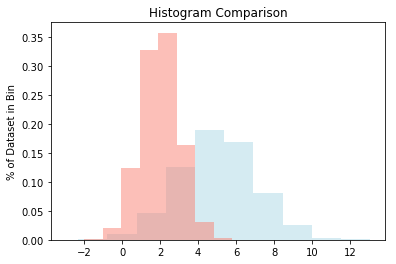

```python
# %load run_me.py
import matplotlib.pyplot as plt
import numpy as np
np.random.seed(1)

x = np.random.normal(5, 2, 10000)
y = np.random.normal(2, 1, 3000000)

xweights = 100 * np.ones_like(x) / x.size
yweights = 100 * np.ones_like(y) / y.size

fig, ax = plt.subplots()
ax.hist(x, weights=xweights, color='lightblue', alpha=0.5, normed=True)
ax.hist(y, weights=yweights, color='salmon', alpha=0.5, normed=True)

ax.set(title='Histogram Comparison', ylabel='% of Dataset in Bin')
ax.margins(0.05)
ax.set_ylim(bottom=0)
plt.show()
```

- run with %run

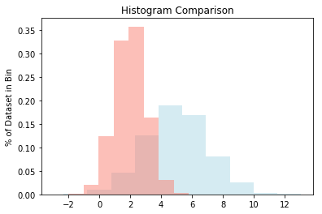

```python
%run run_me.py
```

- Write something to file

```python
%%writefile somepythoncode.py

for n, i in enumerate(range(10), 1):
    print(n, i)
```

```
Overwriting somepythoncode.py
```

- Show contents of a file

```python
%pycat somepythoncode.py
```

```
for n, i in enumerate(range(10), 1):
    print(n, i)
```

Exchange between notebooks with %store

```python
somedata = list(range(20))
%store somedata
del somedata
```

```
Stored 'somedata' (list)
```

```python
%store -r somedata
print(somedata)
```

```
[0, 1, 2, 3, 4, 5, 6, 7, 8, 9, 10, 11, 12, 13, 14, 15, 16, 17, 18, 19]
```

Improve plots output for high resolution displays.

```python
%config InlineBackend.figure_format = 'retina'
```

# # h1

## ## h2

### ### h3

#### #### h4

##### ##### h5

#### Indendations

Creat idendations / citations with **'>'**:

> Hello World!

also for multiple levels **'>'**:

> Hello World!

> > The cellar is

> > > down here

#### Text Fromatting

Basic text formatting is avaibale: *italic*, **bold** oder strikethrough zur Verfügung.

Diese erzeugt man mit

> one * or _ creates: **italic text**

> two * or _ create: __**bold text**__.

#### Lists

can be created like

```
markdown
* Juypter Demo
* Jupter Ecosystem
* Pandas
```

- Juypter Demo
- Jupter Ecosystem
- Pandas

also with miltiple levels:

```
markdown
* Juypter Demo
    * Notebook zeigen
    * Alle begeistern
* Jupter Ecosystem
    * Überblick
    * Highlight und Use Cases
* Pandas
    * Daten I/O
    * Aggregation
    * Modelle:
        * DataSeries *und*
        * DataFrames
    * Visualisierung
```

- Juypter Demo
  - Notebook zeigen
  - Alle begeistern
- Jupter Ecosystem
  - Überblick
  - Highlight und Use Cases
- Pandas
  - Daten I/O
  - Aggregation
  - Modelle:
    - DataSeries *und*
    - DataFrames
  - Visualisierung

numbered lists aree also available:

```
markdown
1. Jupyter
10. Juypter Ecosystem
7. Pandas
```

1. Jupyter
2. Juypter Ecosystem
3. Pandas

*! The right order doesn't matter !*

#### Line breaks

```
Let's
write a
text with a single line break.
```

Let's write a text with a single line break.

```
Let's

write a

text with a single line break.
```

Let's

write a

text with a single line break.

```
Force a line breaks <br/>
with <br/> anywhere<br/> in the text.
```

Force a line breaks  
with  
anywhere  
in the text.

#### Displaying code within markdown

````
markdown
```python
\# Add formatted code into markdown cells.
while True:
    print("Jupyter notebook is quite awesome, isn't it.")
````

```
# Add formatted code into markdown cells.
while True:
    print("Jupyter notebook is quite awesome, isn't it.")
```

#### Formulas with LaTeX

Formulas may be created with the MathJax syntax:

```
$$ P(A \mid B) = \frac{P(B \mid A) \, P(A)}{P(B)} $$
```

$$ P(A \mid B) = \frac{P(B \mid A) \, P(A)}{P(B)} $$

```
$$e^x=\sum_{i=0}^\infty \frac{1}{i!}x^i$$
```

$$e^x=\sum_{i=0}^\infty \frac{1}{i!}x^i$$

#### Tables

Using **|** and *minimum* three **-** create a table.  
Via **:** indicate **---** the desired aligment.

```
|This|is||
|---|:---:|---:|
|a|table|!|
|custom|centered|right|
|One time|is one, two time|one is two|
```

| This | is |  |
| --- | --- | --- |
| a | table | ! |
| custom | centered | right |
| One time | is one, two time | one is two |

#### Embedding pictures

Local source

```
![Lokales PNG](../img/koenigsweg_150.png)
```

[figure not shown]

external source

```
![SVG von Webseite](http://www.koenigsweg.com/src/img/login/koenigsweg-logo.svg)
```

There is also an option to embed pictures via Jupyter.

[figure not shown]

```python
from IPython.display import display, Image

display(Image('../img/koenigsweg_150.png', width=150))
```